# Learning the Ropes Via the Community

@ Oxford SQL Server User Group

## First up

- We're gonna do a little exercise!
- An exercise in helping each other and the organisers
- http://bit.ly/SQLOxfordSurvey
- We'll follow this up a bit later …

[figure not shown]

## Onto business …

## Objective

Learn about:

- the different SQL community activities available
- how they translate into skills you're interested in developing
- who to contact about getting involved

## Attending

- You're doing it right now
- You improve your technical knowledge
- You get to network

Continue as-is

## User group organising

- Either put on events in your local area or assist with the events
- Oxford UG exists, but where are y'all from?
- As a lead organiser, gain lots of organisational skills and improved people skills
- As a team member, gain some organisational skills and improved people skills
- To organise: talk to myself or Craig to help you on the path
- To help Oxford SSUG: talk to Craig or Susy

## Conference organising

- Either BYOC or help with an existing one
- SQLRelay & SQL Saturdays are prime examples
- As a key organiser, gain lots of management, practical, & people skills
- As a team member, gain lots of practical & people skills
- To be main organiser of brand new conf: just get going
- To be a key organiser of existing conf: email / tweet
- To be a team member of existing conf: email / tweet (recommended)

## PASS

- Volunteer portal
- Help at events or get involved with organisation like program selection
- Easier for introverts, gain organisational skills
- Run / assist with a Virtual chapter (see UG slide)
- [PASS website](http://sqlpass.org)

## Helping at events

- On the day helping
- Gain knowledge (room monitoring), people skills
- Keep an eye out for calls for volunteers
- Let organisers know you want to help out
- Offer to help on the day if you notice an extra hand is needed

## Presenting

- From 5 mins to full days
- Excellent way to improve your knowledge, communication and organisation skills
- Talk to your UG leader for a soft start
- Put yourself forward for a lightning talk at events like SQLBits
- Submit sessions when you see a call for speakers

## Blogging

- Disseminate your knowledge to the interwebs
- Great boost to your knowledge, communication and branding skills
- JFDI … Azure website for free anyone?

## Online helping

- Forums like StackOverflow, and the #sqlhelp tag
- Improve knowledge, research and communication skills
- Again, JFDI

## Skills matrix!

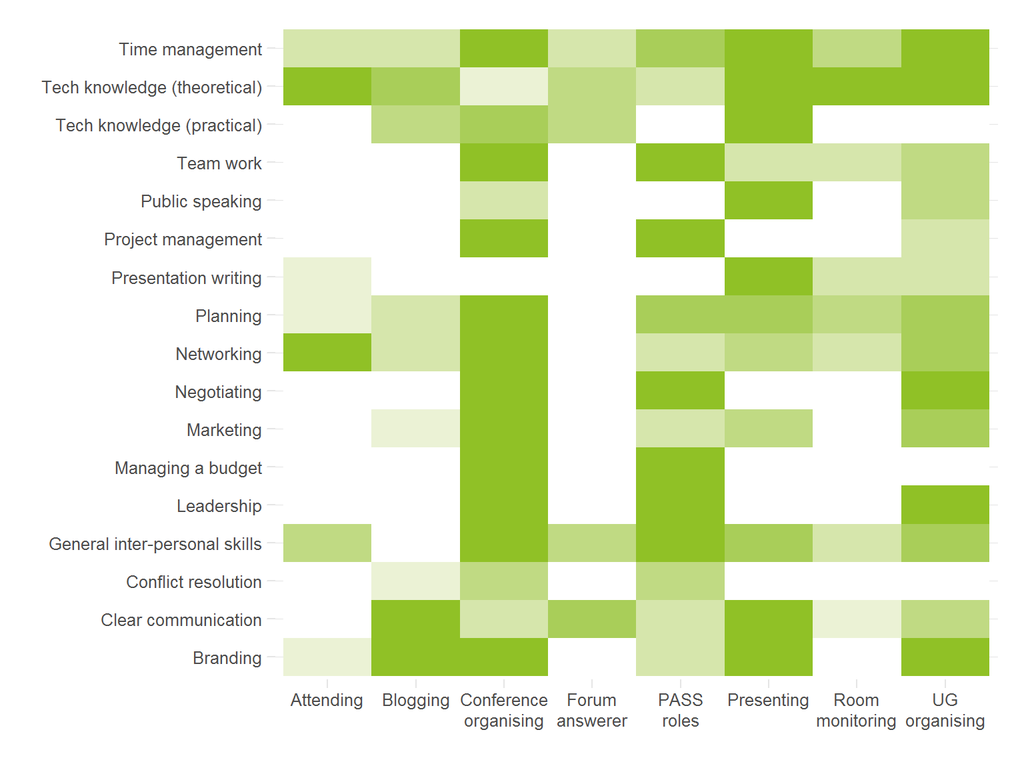

## Conclusion

There's lots of ways you can get involved with the community

I suggest looking at the @SQLRelay account's lists for finding organisers, UGs & conferences to follow

Now back to the exercise!